# BAMexploreR: model-based distribution, abundance, and habitat associations of boreal birds **Introduction**

Welcome! `BAMexploreR` is a package for downloading and analyzing landbird density models produced by the [Boreal Avian Modelling Centre (BAM)](https://borealbirds.ca/).

This vignette provides a general introduction to the `BAMexploreR` package, including background on the BAM landbird density models and versions, an overview of the package purpose, core functionality, and the data included with the package. It highlights the types of data embedded in the package (e.g., shapefiles, species lists) and explains how they support the functions used to explore species occurrence and density across the BCRs’ extent. This is intended as a starting point to familiarize users with the structure and content of the package before diving into specific workflows or analyses.

There are three general categories of tasks that `BAMexploreR` provides:

- **1. Access Models** - download rasters of the model predictions and uncertainty for pre-set regions or custom areas of interest.
- **2. Distribution and Abundance** - explore bird species distribution and estimate population size using the downloaded rasters.
- **3. Habitat Relationships** - explore important predictors of boreal bird abundance and distribution.

In addition to this Introduction vignette, there is a vignette available for each of the three task categories.

## Background

### BAM landbird density models

Reliable information on species’ population sizes, trends, habitat associations, and distributions is crucial for conservation, land-use planning, status assessment, and recovery planning for species at risk. However, the development of such estimates at a national scale is challenged by sparse data coverage in remote regions, differential habitat selection across large geographies, and variation in survey protocols.

With these factors in mind, BAM developed a generalized analytical approach to model landbird species density as a function of environmental features, using in-person or ARU point-count surveys and widely available spatial predictors. We developed separate models for each geographic region (bird conservation regions) based on predictors such as tree species biomass (local and landscape scale), forest age, topography, land use, and climate. We used machine learning to allow for predictor interactions and non-linear responses while avoiding time-consuming species-by-species parameterization. We applied cross-validation to avoid overfitting and bootstrap resampling to estimate uncertainty associated with our density estimates.

**The model products are species-specific predictions of the density of breeding male birds per hectare at a 1km resolution across the boreal forest.**

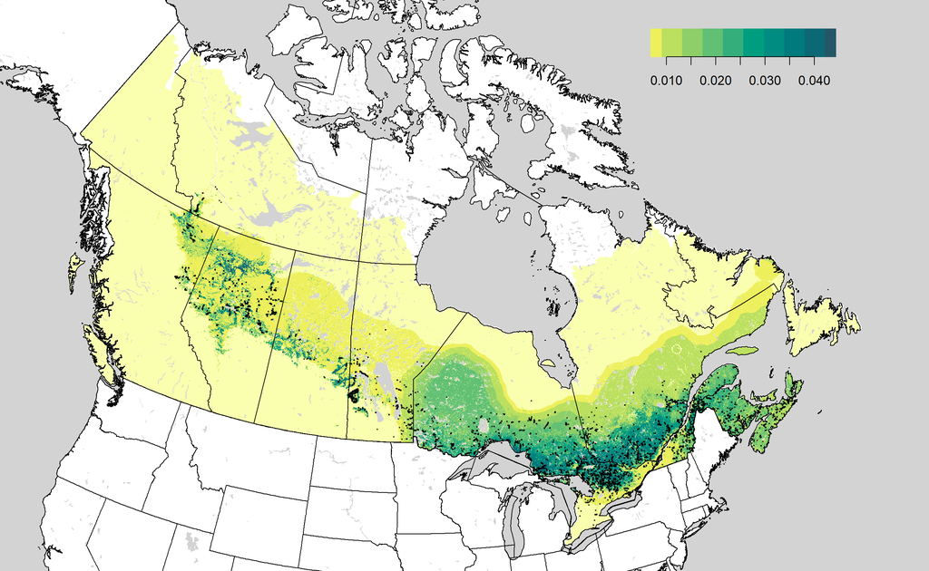

### Model versions

Two versions of the BAM landbird density models are available in `BAMExploreR`.

| Feature | BAM V4 | BAM V5 |
| --- | --- | --- |
| **Release year** | 2020 | 2025 |
| **Species included** | 143 | 67 priority species; 77 in progress |
| **Dataset size** | 0.3 million surveys | 1.4 million surveys, including eBird |
| **Geographic extent** | Canada only | Canada; US boreal & hemiboreal in progress |
| **Temporal resolution** | Predictions for 2017 | Predictions at five-year intervals from 1990 to 2020 |
| **Model subregions** | Bird conservation region (BCR) | Updated BCRs and country |
| **Environmental predictors** | Landcover, biomass, climate | Time-matched predictors for vegetation biomass, human disturbance, and annual climate |
| **Model reliability information** | Cross-validated model performance | Map of coefficient of variation across bootstraps; cross-validated modelperformance, maps of model extrapolation & detection distribution in progress |

## Installation

You can install and load `BAMexploreR` from [GitHub](https://github.com/borealbirds/BAMexploreR) with:

```r
remotes::install_github('borealbirds/BAMExploreR')
library(BAMexploreR)
```

## Syntax

All functions begin with a `bam_*` prefix to facilitate easy autocompletion of the functions when using `BAMExploreR` in RStudio.

## Core Data

There are several types of data embedded in the package to run the functions. Understanding these data types will help you use the functions.

### Species table (spp_tbl)

This reference table serves as a lookup of the species available for each version of the BAM landbird models using four-letter AOU code, common name, or scientific name. The table also provides several ways of grouping species if you are interested in a particular suite of species including species of conservation concern, guild, and classifications from The State of Canada’s Birds report, which organizes species by broad biomes and groups that exhibit distinct and notable population trends.

```r
str(spp_tbl)
'data.frame':   143 obs. of  16 variables:
 $ speciesCode           : chr  "ALFL" "AMCR" "AMGO" "AMPI" ...
 $ commonName            : chr  "Alder Flycatcher" "American Crow" "American Goldfinch" "American Pipit" ...
 $ order                 : chr  "Passeriformes" "Passeriformes" "Passeriformes" "Passeriformes" ...
 $ scientificName        : chr  "Empidonax alnorum" "Corvus brachyrhynchos" "Spinus tristis" "Anthus rubescens" ...
 $ COSEWIC               : int  0 0 0 0 0 0 0 0 0 1 ...
 $ Cavity                : int  0 0 0 0 0 0 1 0 0 0 ...
 $ Waterfowl             : int  0 0 0 0 0 0 0 0 0 0 ...
 $ Marine_Birds          : int  0 0 0 0 0 0 0 0 0 0 ...
 $ Shorebirds            : int  0 0 0 0 0 0 0 0 0 0 ...
 $ Wetland_Birds         : int  1 0 0 0 0 0 0 0 0 0 ...
 $ Birds_of_Prey         : int  0 0 0 0 0 0 0 0 0 0 ...
 $ Forest_Birds          : int  0 0 0 0 1 0 1 0 0 0 ...
 $ Grassland_Birds       : int  0 0 0 0 0 0 0 0 0 0 ...
 $ Aerial_Insectivores   : int  1 0 0 0 0 0 0 0 0 1 ...
 $ Arctic_Birds          : int  0 0 0 0 0 0 0 0 0 0 ...
 $ Long_Distance_Migrants: int  1 1 1 1 1 0 1 1 1 1 ...
```

### Modelling region maps (BAM_BCRNMv4, BAM_BCRNMv5)

These two objects are SpatVectors containing the boundaries of the modelling subunits for versions 4 and 5. The package also provides helper functions to retrieve the names of subunits corresponding to a specified version and easily visualize (map) those subunits within your analysis workflow (see ‘Model Access’ vignette).

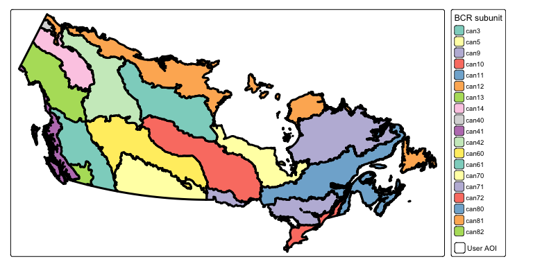

### Model predictor metadata

This reference table can be used to understand the different predictors that went into the BAM landbird density models, including a description and source for each, as well as the classes they are grouped into for some of the habitat relationship functions.

```r
#Look at the column names
colnames(predictor_metadata)
 [1] "version"               "predictor"             "definition"
 [4] "predictor_class"       "resolution"            "source"
 [7] "provider"              "citation"              "covariate_extraction"
[10] "prediction_resolution" "years"                 "temporal_matching"

#Look at the first three rows for a few predictors
predictor_metadata |>
  dplyr::select(version, predictor, definition, predictor_class) |>
  head(3)
  version    predictor                            definition predictor_class
1      v5   ERAMAP_1km       Mean Annual Precipitation (MAP)  Annual Climate
2      v5   ERAMAT_1km         Mean Annual Temperature (MAT)  Annual Climate
3      v5 ERAPPTsm_1km Summer (Jun to Aug) (S) Precipitation  Annual Climate
```

## Citation

To cite `BAMexploreR` package and the BAM density models in publications, please cite the package and the publication:

Houle M, Boehm M, Wu S, Knight E (2026). *BAMexploreR: model-based density, distribution, and habitat associations of boreal birds*. R package version 0.1.0, https://github.com/borealbirds/BAMexploreR.

Stralberg D, Sólymos P, Docherty T, Crosby A, Van Wilgenburg S, Knight E, Drake A, Boehm M, Haché S, Leston L, Toms J, Ball J, Song S, Schmiegelow F, Cumming S, Bayne E (In press). “A generalized modeling framework for spatially extensive species abundance prediction and population estimation.” *Ecosphere*.